# 01_preprocessing - participant 43

Bram Zandbelt

June 19, 2019

# 1 Overview

This notebook performs **cleaning** and **quality assessment** of an individual participant’s data. It takes as input a participant’s raw trial log file and produces as output an overview of the task performance criteria that are met and unmet, a visualization of the indifference points estimated from the calibration task, and multiple csv files written to disk containing cleaned data from different subsets of trials.

# 2 Preliminaries

Before reading the data the following is specified:

```r
notebook_name <-
   stringr::str_to_lower(stringr::str_replace_all(params$title, " ", "_"))
```

- the *name of the notebook (`notebook_name`)*, which is used to save output to a notebook-specific directory

```r
# Raw trial log files are read from here
raw_data_dir <-
  file.path("data","raw")

# Cleaned data will be written here
preproc_data_dir <-
  file.path("data","derivatives", notebook_name)
preproc_incl_data_dir <-
  file.path(preproc_data_dir, "included")
preproc_excl_performance_data_dir <-
  file.path(preproc_data_dir, "excluded_performance")
preproc_excl_software_error_data_dir <-
  file.path(preproc_data_dir, "excluded_software_error")

# Create non-existing dirs if they don't exist
cmdsddfeitc::check_dir(all_dirs = c(raw_data_dir,
                                    preproc_data_dir,
                                    preproc_incl_data_dir,
                                    preproc_excl_performance_data_dir,
                                    preproc_excl_software_error_data_dir)
                       )
```

- all *relevant directories* for reading and writing data

```r
# Determine which file should be read
trial_log_filename <- list.files(path = raw_data_dir,
                                 pattern = sprintf("trial_log.*%.3d.csv", params$participant_id[[1]])
                                 )

# Determine task version, because factor levels (e.g. framing, trial_type) are task-dependent
task_version <- ifelse(stringr::str_detect(trial_log_filename, "defer_speedup"),
                    "defer_speedup",
                    ifelse(stringr::str_detect(trial_log_filename, "date_delay"),
                           "date_delay",
                           NA
                           )
                    )
```

- the *filename of the trial log file (`trial_log_filename`)* and *task version (`task_version`)*

```r
crit <- list()

## Trial numbers
crit$n_trial$practice = 10
crit$n_trial$calibration$defer_speedup = 70 # 7 delays * (7 standard + 3 control trials)
crit$n_trial$calibration$date_delay = 63 # 7 delays * (7 standard + 2 control trials)
crit$n_trial$experiment$defer_speedup = 276 # 3 blocks of 92 trials
crit$n_trial$experiment$date_delay = 184 # 2 blocks of 92 trials

## Minimum accuracy on control trials
crit$min_accuracy_control = 0.75

## Maximum proportion of fast responses (RT < 1500 ms)
crit$max_proportion_too_fast_rt = 0.25

## Maximum proportion of omission errors (no response recorded)
crit$max_proportion_omission_error = 0.25

## Additional criterion: maximum proportion of SS or LL choice option, collapsed across framing conditions, delays, etc. (i.e. to detect extreme choice patterns)
crit$max_proportion_any_choice = 0.95

## Additional criterion: maximum number of standard trials on which m_s > m_l (i.e. this relates to a bug in the task code that affected participants with indifference points close to m_l at long delays, for fix see https://github.com/bramzandbelt/itch_time_framing_task/commit/9723ef2628a1f7cd87b029545ebba39df8cd7b40)
crit$max_n_standard_trials_ms_greater_than_ml = 0
```

- the preset *task performance criteria (`crit`)* (see preregistration document, https://osf.io/cmdp2/) that are used to benchmark performance:
- number of trials for each stage should be:
  - practice: 10
  - calibration: a multiple of 63
  - experiment: 184
- minimum accuracy on control trials: 0.75
- maximum proportion of fast responses (RT < 1500 ms): 0.25
- maximum proportion of omission_errors (RT > 10000 ms): 0.25
- additional criterion: maximum proportion of one option (i.e. to exclude participants with extreme choice patterns, (almost) always chooing the same option)
- additional criterion: maximum number of standard trials on which m_s > m_l (i.e. this relates to a bug in the task code that affected participants with indifference points close to m_l at long delays)

# 3 Read data

Having specified all relevant variables, the raw trial log is read:

```r
# Read (and print) the data, using task-dependent column specifications
(raw_data <-
    readr::read_csv(file = file.path(raw_data_dir, trial_log_filename),
                    col_types = cmdsddfeitc::get_col_types(stringr::str_c("trial_log_data_", task_version)))
  )
```

| subject_ix | session_ix | block_id | block_ix | iter_ix | framing | trial_type | m_s_cat | m_s | m_l | t_s | t_l | choice | rt | trial_correct | too_fast |
| --- | --- | --- | --- | --- | --- | --- | --- | --- | --- | --- | --- | --- | --- | --- | --- |
| 43 | 1 | p000 | 0 | 0 | neutral | standard | NA | 5.00 | 50.00 | 0 | 16 | ll | 4.8570190 | TRUE | FALSE |
| 43 | 1 | p000 | 0 | 0 | neutral | standard | NA | 10.00 | 50.00 | 0 | 16 | ll | 3.5762220 | TRUE | FALSE |
| 43 | 1 | p000 | 0 | 0 | neutral | standard | NA | 15.00 | 50.00 | 0 | 16 | ll | 3.3750103 | TRUE | FALSE |
| 43 | 1 | p000 | 0 | 0 | neutral | standard | NA | 20.00 | 50.00 | 0 | 16 | ll | 1.9696640 | TRUE | FALSE |
| 43 | 1 | p000 | 0 | 0 | neutral | standard | NA | 25.00 | 50.00 | 0 | 16 | ll | 1.4966190 | TRUE | TRUE |
| 43 | 1 | p000 | 0 | 0 | neutral | standard | NA | 30.00 | 50.00 | 0 | 16 | ll | 1.9578182 | TRUE | FALSE |
| 43 | 1 | p000 | 0 | 0 | neutral | standard | NA | 35.00 | 50.00 | 0 | 16 | ll | 1.4389934 | TRUE | TRUE |
| 43 | 1 | p000 | 0 | 0 | neutral | standard | NA | 40.00 | 50.00 | 0 | 16 | ss | 4.4600336 | TRUE | FALSE |
| 43 | 1 | p000 | 0 | 0 | neutral | standard | NA | 45.00 | 50.00 | 0 | 16 | ss | 3.9991110 | TRUE | FALSE |
| 43 | 1 | p000 | 0 | 0 | neutral | standard | NA | 50.00 | 50.00 | 0 | 16 | ss | 2.3203219 | TRUE | FALSE |

[output cut: 247 more lines]

# 4 Preprocess data

## 4.1 Data cleaning

Data cleaning encompasses the following steps for the following reasons:

1. correct erroneous coding of variable names ending with `_ix` (e.g. `block_ix`, `iter_ix`) from double to integer
2. add a factor variable `stage_id` to enable grouping and computing of quality assessment and summary statistics separately for practice, calibration, and experiment stages;
3. add a logical variable `omission_error` to ease quality assessment
4. rename the variable `framing` to `frame`, as it is used in the `itchmodel` package

```r
all_trials_cleaned <-
  raw_data %>%
  # Code integers as integers
  dplyr::mutate_at(vars(dplyr::ends_with("ix")),
                  as.integer) %>%
  # Add variable stage_id
  dplyr::mutate(stage_id =
                  dplyr::case_when(stringr::str_detect(raw_data$block_id, "^p")
                                   ~ "practice",
                                   stringr::str_detect(raw_data$block_id, "^i")
                                   ~ "calibration",
                                   stringr::str_detect(raw_data$block_id, "^e")
                                   ~ "experiment"
                                   )
                ) %>%
  dplyr::mutate(stage_id = factor(stage_id,
                                  levels = c("practice",
                                             "calibration",
                                             "experiment"),
                                  ordered = TRUE)) %>%
  # Add variable omission_error
  dplyr::mutate(omission_error = is.infinite(rt)) %>%
  dplyr::rename(frame = framing) %>%
  # Exclude repeated stages (e.g. due to failure to meet calibration criteria or accidentally quiting the experiment, in participant_id = 92)
  dplyr::group_by(stage_id) %>%
  dplyr::filter(session_ix == max(unique(session_ix)),
                iter_ix == max(unique(iter_ix))) %>%
  dplyr::ungroup()
```

## 4.2 Data selection

```r
# First identify relevant columns for assessing the data from the calibration and experiment task
rel_cols <- c("subject_ix", # participant index
              "stage_id", # practice, calibration (ip procedure), experiment
              "block_id", # (p)ractice, (i)p procedure, (e)xperiment
              "block_ix", # block index
              "iter_ix",  # iteration index
              "frame",    # time frame used
              "m_s",      # amount of smaller-sooner option
              "m_s_cat",  # category: below, at, or above IP
              "m_l",      # amount of larger-later option
              "t_s",      # delay to the smaller-sooner option
              "t_l",      # delay to the larger-later option
              "trial_type", # standard, catch, or instruction manipulation check
              "choice",  # smaller-sooner (SS) or larger-later (LL) option
              "response", # upper (LL) or lower (SS) bound
              "rt",      # response time
              "trial_correct", # whether or not response was correct
              "too_fast",  # whether or not response was fast
              "omission_error" # whether or not a response is lacking
              )

# Smaller-sooner amount category (m_s_cat, with levels below, at, and above IP) does not exist at the calibration stage
rel_cols_clbr <- rel_cols[!(rel_cols %in% c("m_s_cat", "response"))]

# The iteration index is only used in the calibration task (to count how often participants have to repeat the task in order to comply with performance criteria)
rel_cols_expt <- rel_cols[rel_cols %in% c("subject_ix", "frame", "m_s_cat", "m_s", "m_l", "t_s", "t_l", "choice", "response", "rt")]
```

Data selection involves taking the cleaned data (`all_trials_cleaned`) to define three additional subsets for the following purposes:

1. standard trials from the calibration task (`clbr_trials_standard`) will be used to visualize estimated indifference points and written to disk for further (exploratory) analysis

```r
# Standard trials from the calibration task will be written to disk for further analysis
(clbr_trials_standard <-
    all_trials_cleaned %>%
    dplyr::filter(stage_id == "calibration") %>%
    # # Only the last block needed: performance did not meet criteria in earlier blocks
    # dplyr::filter(iter_ix == max(unique(iter_ix))) %>%
    dplyr::select(rel_cols_clbr) %>%
    dplyr::filter(trial_type %in% "standard"))
```

| subject_ix | stage_id | block_id | block_ix | iter_ix | frame | m_s | m_l | t_s | t_l | trial_type | choice | rt | trial_correct | too_fast | omission_error |
| --- | --- | --- | --- | --- | --- | --- | --- | --- | --- | --- | --- | --- | --- | --- | --- |
| 43 | calibration | i000 | 0 | 0 | neutral | 21.76 | 43.52 | 0 | 2 | standard | ll | 10.6370541 | TRUE | FALSE | FALSE |
| 43 | calibration | i000 | 0 | 0 | neutral | 32.64 | 43.52 | 0 | 2 | standard | ll | 2.7962610 | TRUE | FALSE | FALSE |
| 43 | calibration | i000 | 0 | 0 | neutral | 38.08 | 43.52 | 0 | 2 | standard | ll | 2.3799134 | TRUE | FALSE | FALSE |
| 43 | calibration | i000 | 0 | 0 | neutral | 40.80 | 43.52 | 0 | 2 | standard | ll | 2.0684355 | TRUE | FALSE | FALSE |
| 43 | calibration | i000 | 0 | 0 | neutral | 42.16 | 43.52 | 0 | 2 | standard | ll | 6.8469094 | TRUE | FALSE | FALSE |
| 43 | calibration | i000 | 0 | 0 | neutral | 42.84 | 43.52 | 0 | 2 | standard | ll | 6.3894546 | TRUE | FALSE | FALSE |
| 43 | calibration | i000 | 0 | 0 | neutral | 43.18 | 43.52 | 0 | 2 | standard | ss | 2.5314528 | TRUE | FALSE | FALSE |
| 43 | calibration | i000 | 0 | 0 | neutral | 21.76 | 43.52 | 0 | 4 | standard | ll | 3.2241771 | TRUE | FALSE | FALSE |
| 43 | calibration | i000 | 0 | 0 | neutral | 32.64 | 43.52 | 0 | 4 | standard | ll | 2.3339231 | TRUE | FALSE | FALSE |
| 43 | calibration | i000 | 0 | 0 | neutral | 38.08 | 43.52 | 0 | 4 | standard | ll | 1.8852715 | TRUE | FALSE | FALSE |

[output cut: 39 more lines]

2. standard trials from the experiment task (`expt_trials_standard`) will be written to disk for modeling analysis

```r
# Standard trials from the experiment will be written to disk for further analysis
(expt_trials_standard <-
   all_trials_cleaned %>%
   dplyr::filter(stage_id == "experiment",
                 trial_type %in% "standard",
                 too_fast == FALSE,
                 omission_error == FALSE
                 ) %>%
   # # Only the last block, in case an error occurred (e.g. in participant ID 92)
   # dplyr::filter(iter_ix == max(unique(iter_ix))) %>%
   dplyr::mutate(response = ifelse(choice == "ll",
                                  "upper",
                                  ifelse(choice == "ss",
                                         "lower",
                                         NA)
                                  )
                 ) %>%
   dplyr::select(rel_cols_expt)
 )
```

| subject_ix | frame | m_s | m_s_cat | m_l | t_s | t_l | choice | response | rt |
| --- | --- | --- | --- | --- | --- | --- | --- | --- | --- |
| 43 | delay | 37.06 | below_ip | 43.52 | 0 | 64 | ll | upper | 3.439393 |
| 43 | delay | 38.42 | at_ip | 43.52 | 0 | 128 | ss | lower | 3.808559 |
| 43 | delay | 41.48 | above_ip | 43.52 | 0 | 32 | ss | lower | 2.516638 |
| 43 | delay | 43.35 | above_ip | 43.52 | 0 | 2 | ss | lower | 2.720468 |
| 43 | delay | 38.42 | at_ip | 43.52 | 0 | 128 | ll | upper | 3.134901 |
| 43 | delay | 36.04 | below_ip | 43.52 | 0 | 128 | ll | upper | 3.071547 |
| 43 | delay | 39.10 | at_ip | 43.52 | 0 | 64 | ss | lower | 2.434413 |
| 43 | delay | 38.42 | at_ip | 43.52 | 0 | 128 | ss | lower | 3.492225 |
| 43 | delay | 38.08 | below_ip | 43.52 | 0 | 32 | ss | lower | 3.015484 |
| 43 | delay | 39.78 | at_ip | 43.52 | 0 | 32 | ss | lower | 3.677381 |

[output cut: 156 more lines]

3. control trials from both the calibration task and the experiment task (`control_trials`)

```r
# Control trials will be used for assessing whether participants paid attention
(control_trials <-
    all_trials_cleaned %>%
    dplyr::filter(!trial_type %in% "standard"))
```

| subject_ix | session_ix | block_id | block_ix | iter_ix | frame | trial_type | m_s_cat | m_s | m_l | t_s | t_l | choice | rt | trial_correct | too_fast | stage_id | omission_error |
| --- | --- | --- | --- | --- | --- | --- | --- | --- | --- | --- | --- | --- | --- | --- | --- | --- | --- |
| 43 | 1 | i000 | 0 | 0 | neutral | catch_ll | NA | 0.00 | 43.52 | 0 | 2 | ll | 5.741432 | TRUE | FALSE | calibration | FALSE |
| 43 | 1 | i000 | 0 | 0 | neutral | catch_ss | NA | 43.52 | 43.52 | 0 | 2 | ss | 5.025154 | TRUE | FALSE | calibration | FALSE |
| 43 | 1 | i000 | 0 | 0 | neutral | catch_ss | NA | 43.52 | 43.52 | 0 | 4 | ss | 4.480521 | TRUE | FALSE | calibration | FALSE |
| 43 | 1 | i000 | 0 | 0 | neutral | catch_ll | NA | 0.00 | 43.52 | 0 | 4 | ll | 1.681624 | TRUE | FALSE | calibration | FALSE |
| 43 | 1 | i000 | 0 | 0 | neutral | catch_ll | NA | 0.00 | 43.52 | 0 | 8 | ll | 2.700022 | TRUE | FALSE | calibration | FALSE |
| 43 | 1 | i000 | 0 | 0 | neutral | catch_ss | NA | 43.52 | 43.52 | 0 | 8 | ss | 3.317189 | TRUE | FALSE | calibration | FALSE |
| 43 | 1 | i000 | 0 | 0 | neutral | catch_ll | NA | 0.00 | 43.52 | 0 | 16 | ll | 1.795677 | TRUE | FALSE | calibration | FALSE |
| 43 | 1 | i000 | 0 | 0 | neutral | catch_ss | NA | 43.52 | 43.52 | 0 | 16 | ss | 3.167580 | TRUE | FALSE | calibration | FALSE |
| 43 | 1 | i000 | 0 | 0 | neutral | catch_ll | NA | 0.00 | 43.52 | 0 | 32 | ll | 2.470300 | TRUE | FALSE | calibration | FALSE |
| 43 | 1 | i000 | 0 | 0 | neutral | catch_ss | NA | 43.52 | 43.52 | 0 | 32 | ss | 2.913656 | TRUE | FALSE | calibration | FALSE |

[output cut: 20 more lines]

## 4.3 Identify calibration task indifference points

Indifference points in the calibration task are defined as the smaller-sooner amount (`m_s`) on the last standard trial of each delay.

```r
(calibration_indifference_points <-
  clbr_trials_standard %>%
  # We're interested in catch trials and instruction manipulation check trials
  dplyr::select(subject_ix, t_l, m_s) %>%
  # Last trial is approximate indifference point
  dplyr::group_by(subject_ix, t_l) %>%
  dplyr::summarize(ip = dplyr::last(m_s)) %>%
  dplyr::mutate(relative_diff = c(NA, diff(ip))/ 43.52,
                relative_diff_crit_met = (relative_diff < 0.2 | is.na(relative_diff)),
                last_ip_within_bounds = c(rep(TRUE,6),
                                          dplyr::last(ip) >= 0.17 &
                                          dplyr::last(ip) <= 43.52 - 0.17),
                monotonic_decrease = relative_diff_crit_met & last_ip_within_bounds))
```

| subject_ix | t_l | ip | relative_diff | relative_diff_crit_met | last_ip_within_bounds | monotonic_decrease |
| --- | --- | --- | --- | --- | --- | --- |
| 43 | 2 | 43.18 | NA | TRUE | TRUE | TRUE |
| 43 | 4 | 41.14 | -0.046875 | TRUE | TRUE | TRUE |
| 43 | 8 | 41.14 | 0.000000 | TRUE | TRUE | TRUE |
| 43 | 16 | 39.78 | -0.031250 | TRUE | TRUE | TRUE |
| 43 | 32 | 39.78 | 0.000000 | TRUE | TRUE | TRUE |
| 43 | 64 | 39.10 | -0.015625 | TRUE | TRUE | TRUE |
| 43 | 128 | 38.42 | -0.015625 | TRUE | TRUE | TRUE |

# 5 Analyze data

We benchmark the following performance criteria:

- **number of trials (`n_trial`)** in each stage: to verify that all required data is collected (e.g. if participant fails to meet performance criteria in the calibration task three times, no further experimental data is collected);
- **accuracy on control trials (`accuracy_control`)** in the calibration and experiment stage: to verify that participants paid attention to the choice options and trial instruction;
- **proportion of trials with fast (< 1500 ms) responses (`proportion_too_fast_rt`)** in the calibration and experiment stage: to verify that participants consider each scenario carefully;
- **proportion of trials with omission errors (`proportion_omission_error`)** in the calibration and experiment stage: to verify that participants response within the 10000 ms response deadline.

```r
# Benchmark trial numbers
trial_numbers <-
  all_trials_cleaned %>%
  dplyr::group_by(stage_id) %>%
  # dplyr::filter(iter_ix == max(unique(iter_ix))) %>%
  dplyr::summarize(criterion = "n_trial",
                   value = n()) %>%
  tidyr::complete(stage_id, fill = list(criterion = "n_trial", value = 0)) %>%
  dplyr::mutate(criterion_met =
                  dplyr::case_when((.$stage_id == "practice" &
                                      .$value == 10)
                                   ~ TRUE,
                                   (.$stage_id == "practice" &
                                      .$value != 10)
                                   ~ FALSE,
                                   (.$stage_id == "calibration" &
                                      .$value %% crit$n_trial$calibration[[task_version]] == 0)
                                   ~ TRUE,
                                   (.$stage_id == "calibration" &
                                      .$value %% crit$n_trial$calibration[[task_version]] != 0)
                                   ~ FALSE,
                                   (.$stage_id == "experiment" &
                                      .$value == crit$n_trial$experiment[[task_version]])
                                   ~ TRUE,
                                   (.$stage_id == "experiment" &
                                      .$value != crit$n_trial$experiment[[task_version]])
                                   ~ FALSE
                                   )
                )

# Benchmark control trial accuracy
accuracy_control_trials <-
  control_trials %>%
  dplyr::group_by(stage_id) %>%
  dplyr::summarize(criterion = "accuracy_control",
                   value = sum(trial_correct) / n()) %>%
  dplyr::mutate(criterion_met =
                  ifelse(value >= crit$min_accuracy_control,
                         TRUE,
                         FALSE)
                  )

# Benchmark proportion of fast responses
proportion_too_fast_rt <-
  all_trials_cleaned %>%
  dplyr::filter(stage_id %in% c("calibration", "experiment"),
                trial_type == "standard") %>%
  dplyr::group_by(stage_id) %>%
  dplyr::summarize(n = n(),
                   n_too_fast = sum(too_fast == TRUE),
                   criterion = "proportion_too_fast",
                   value = n_too_fast / n) %>%
  dplyr::select(-n, -n_too_fast) %>%
  dplyr::mutate(criterion_met =
                  ifelse(value <= crit$max_proportion_too_fast_rt,
                         TRUE,
                         FALSE)
                  )

# Benchmark proportion of omission errors
proportion_omission_error <-
  all_trials_cleaned %>%
  dplyr::filter(stage_id %in% c("calibration", "experiment"),
                trial_type == "standard") %>%
  dplyr::group_by(stage_id) %>%
  dplyr::summarize(n = n(),
                   n_omission_error = sum(omission_error == TRUE),
                   criterion = "proportion_omission_error",
                   value = n_omission_error / n) %>%
  dplyr::select(-n, -n_omission_error) %>%
  dplyr::mutate(criterion_met =
                  ifelse(value <= crit$max_proportion_omission_error,
                         TRUE,
                         FALSE)
                  )

# Benchmark proporion of SS and LL choices
proportion_choice_options <-
  expt_trials_standard %>%
  dplyr::count(response) %>%
  dplyr::mutate(value = n / sum(n)) %>%
  dplyr::arrange(-value) %>%
  dplyr::slice(1) %>%
  dplyr::mutate(stage_id = factor("experiment", levels = c("practice", "calibration", "experiment"), ordered = TRUE),
                criterion = "max_proportion_any_choice",
                criterion_met =
                  ifelse(value < crit$max_proportion_any_choice,
                         TRUE,
                         FALSE)
                ) %>%
  dplyr::select(stage_id, criterion, value, criterion_met)

# Benchmark number of standard trials on which ms > m_l
n_standard_trials_ms_greater_than_ml <-
  expt_trials_standard %>%
  dplyr::filter (m_s > m_l) %>%
  dplyr::count() %>%
  dplyr::rename(value = n) %>%
  dplyr::mutate(stage_id = factor("experiment", levels = c("practice", "calibration", "experiment"), ordered = TRUE),
                criterion = "max_n_standard_trials_ms_greater_than_ml",
                criterion_met =
                  ifelse(value <= crit$max_n_standard_trials_ms_greater_than_ml,
                         TRUE,
                         FALSE)
                )

# Show all benchmarks
(all_benchmarks <-
dplyr::bind_rows(trial_numbers,
                 accuracy_control_trials,
                 proportion_too_fast_rt,
                 proportion_omission_error,
                 proportion_choice_options,
                 n_standard_trials_ms_greater_than_ml
                 ))
```

| stage_id | criterion | value | criterion_met |
| --- | --- | --- | --- |
| practice | n_trial | 10.00000000 | TRUE |
| calibration | n_trial | 63.00000000 | TRUE |
| experiment | n_trial | 184.00000000 | TRUE |
| calibration | accuracy_control | 1.00000000 | TRUE |
| experiment | accuracy_control | 1.00000000 | TRUE |
| calibration | proportion_too_fast | 0.04081633 | TRUE |
| experiment | proportion_too_fast | 0.01190476 | TRUE |
| calibration | proportion_omission_error | 0.00000000 | TRUE |
| experiment | proportion_omission_error | 0.00000000 | TRUE |
| experiment | max_proportion_any_choice | 0.56024096 | TRUE |

[output cut: 1 more lines]

```r
# Determine if all criteria were met
all_criterion_met <- all(all_benchmarks$criterion_met)

if (all_criterion_met) {
    print("All criteria were met: participant INCLUDED for further analysis")
  } else {
    print("Not all criteria were met: participant EXCLUDED for further analysis")
  }
```

```
## [1] "All criteria were met: participant INCLUDED for further analysis"
```

# 6 Visualize data

Visualize the calibration task indifference points

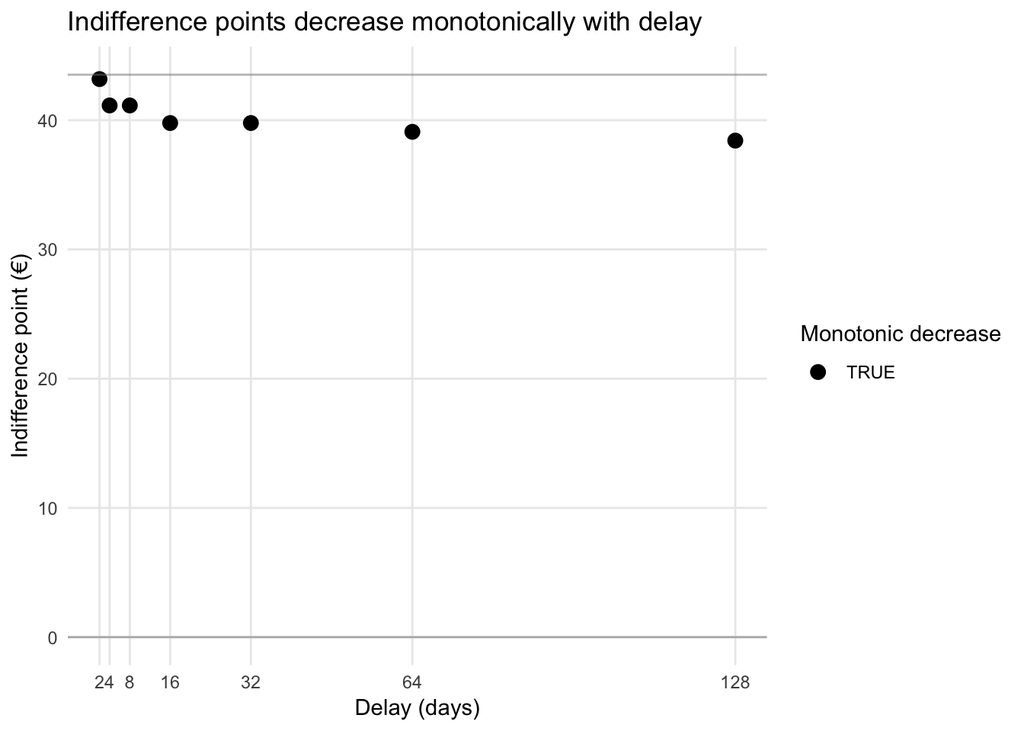

```r
if (params$visualize) {
 title_str <- ifelse(all(calibration_indifference_points$monotonic_decrease),
                    "Indifference points decrease monotonically with delay",
                    expression(paste("Indifference points ", bold("do not"), " decrease monotonically with delay"))
                    )

if (all(calibration_indifference_points$monotonic_decrease)) {
  color_vals <- c("black", "red") # Two values must be provided, but only first will be used
} else {
  color_vals <- c("red", "black")
}

ggplot2::ggplot(calibration_indifference_points,
                ggplot2::aes(x = t_l,
                             y = ip,
                             color = monotonic_decrease)
                ) +

  # Geoms
  ggplot2::geom_point(shape = 19,
                      size = 3) +

  ggplot2::geom_hline(yintercept = 43.52, color = "gray50", linetype = "solid", size = 0.5, alpha = 0.5) +
  ggplot2::geom_hline(yintercept = 0, color = "gray50", linetype = "solid", size = 0.5, alpha = 0.5) +

  # Scales
  ggplot2::scale_color_manual(name = "Monotonic decrease",
                                values = color_vals) +

  ggplot2::scale_x_continuous(name = "Delay (days)",
                              breaks = c(2,4,8,16,32,64,128),
                              labels = c(2,4,8,16,32,64,128)) +
  ggplot2::scale_y_continuous(name = "Indifference point (€)",
                              limits = c(0,43.52)) +

  # Title
  ggplot2::ggtitle(title_str) +

  # Theme
  ggplot2::theme_minimal() +
  ggplot2::theme(panel.grid.minor = ggplot2::element_blank())
}
```

# 7 Write data to disk

The directory in which the cleaned data will be written depends on whether the dataset was compromised because of a coding error in the stimulus presentation software (`preproc_excl_software_error_data_dir`) and if not, whether all performance criteria were met (`preproc_incl_data_dir`) or not (`preproc_excl_performance_data_dir`).

```r
# Define output directory based on whether all performance criteria were met
data_output_dir <-
  ifelse(!n_standard_trials_ms_greater_than_ml$criterion_met,
         preproc_excl_software_error_data_dir,
         ifelse(all_criterion_met,
                preproc_incl_data_dir,
                preproc_excl_performance_data_dir
                )
         )
```

We write 4 files to disk:

1. calibration task data (final block only), which will be used for exploratory analysis of the indifference point procedure:

```r
# Calibration task: used for exploratory data analysis
clbr_trials_standard_file <-
  file.path(data_output_dir,
            sprintf("calibration_standard_trials_task-%s_pid-%.3d.csv",
                    task_version,
                    params$participant_id # pid
                    )
            )
readr::write_csv(clbr_trials_standard,
                 path = clbr_trials_standard_file
            )
print(sprintf("%s", clbr_trials_standard_file))
```

```
## [1] "data/derivatives/01_preprocessing/included/calibration_standard_trials_task-date_delay_pid-043.csv"
```

2. experimental task data, which will be used for computational modeling and control analyses:

```r
# Standard trials from experiment: used for modeling
expt_trials_standard_file <-
  file.path(data_output_dir,
            sprintf("experiment_standard_trials_task-%s_pid-%.3d.csv",
                    task_version,
                    params$participant_id # pid
                    )
            )

readr::write_csv(expt_trials_standard,
                 path = expt_trials_standard_file
            )
print(sprintf("%s", expt_trials_standard_file))
```

```
## [1] "data/derivatives/01_preprocessing/included/experiment_standard_trials_task-date_delay_pid-043.csv"
```

3. indifference points from the calibration task:

```r
# Standard trials from experiment: used for modeling
calibration_indifference_points_file <-
  file.path(data_output_dir,
            sprintf("calibration_indifference_points_pid-%.3d.csv",
                    params$participant_id # pid
                    )
            )

readr::write_csv(calibration_indifference_points %>%
                   dplyr::select(subject_ix, t_l, ip),
                 path = calibration_indifference_points_file
            )
print(sprintf("%s", calibration_indifference_points_file))
```

```
## [1] "data/derivatives/01_preprocessing/included/calibration_indifference_points_pid-043.csv"
```

4. benchmark results:

```r
benchmark_results_file <-
  file.path(data_output_dir,
            sprintf("benchmark_results_task-%s_pid-%.3d.csv",
                    task_version,
                    params$participant_id # pid
                    )
            )

readr::write_csv(all_benchmarks %>%
                   dplyr::mutate(participant_id = params$participant_id) %>%
                   dplyr::select(participant_id, dplyr::everything()),
                 path = benchmark_results_file
            )
print(sprintf("%s", benchmark_results_file))
```

```
## [1] "data/derivatives/01_preprocessing/included/benchmark_results_task-date_delay_pid-043.csv"
```